# Homework Assignment 1

Author

Krish Patel

Published

January 21, 2024

Got familiar with the use of Quarto, JS web editor, and Expo, utilizing VS Code synergetic environment using the tools downloaded in the assignment.

# Software Installation

Yes, I installed the necessary software. Below is a screen shot showing the versions of the software that I’ve got running on my machine. These programs are all on the PATH and can all be run from the command line, too!

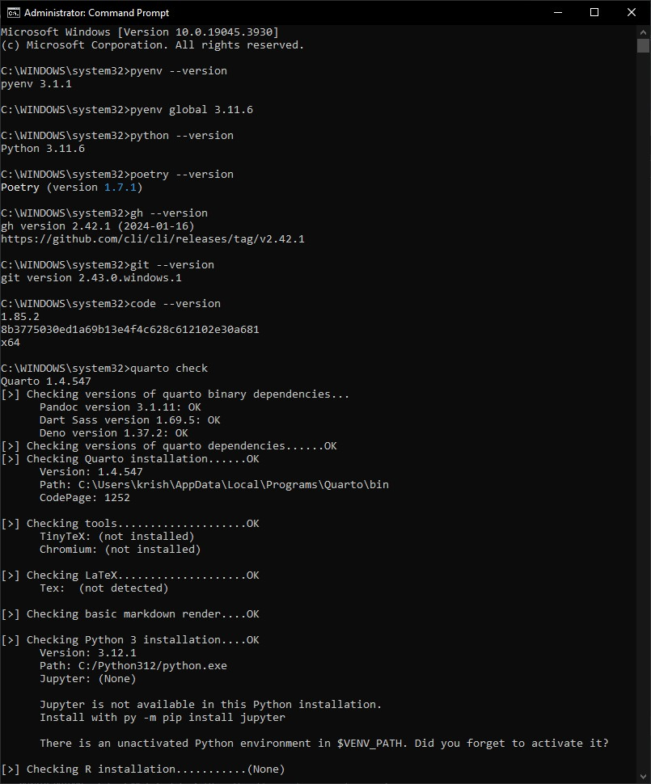

**Instructions***:* Your job is to modify the [markdown image link](https://quarto.org/docs/authoring/markdown-basics.html#links-images) above with an image that you create. I generally store images in an *assets* fomder directly under the folder containing my main report folders.*

We’ll be looking that you installed and can run from the command line:

1. quarto
2. code (visual studio code)
3. git
4. gh
5. pyenv
6. poetry
7. python

# Setting up accounts

As part of homework assignment 1, you’ll also need to create a few accounts.

As part of this homework assignment, you’ll be embedding URLs to demonstrate that you’ve got your accounts!.

## P5JS

P5.js is a JavaScript library that simplifies creative coding and interactive visual design. It provides a framework for teaching UI design by enabling students to easily create and manipulate graphics, animations, and interactive elements within web applications. With its intuitive syntax and built-in drawing functions, P5.js empowers learners to experiment with user interface concepts, fostering a hands-on approach to understanding UI design principles and techniques.

The first two modules of the course will leverage the [P5JS](https://p5js.org/) framework. To get started, you’ll need to visit the site and [create an account](https://editor.p5js.org/signup).

Once you create your account, experiment around until you create an image that looks like the one below.

[interactive chart not shown]

**Instructions:** Your job is to modify the *src* tag above with a screen that reflects that you created your account and modified the code with your name.

## EXPO and snacks

Yes, I set up my expo account and created a sample expo application. Below is a link to my customized app.

[interactive chart not shown]

# Reflection

Enjoyed hands-on experimenting with different applications and software. Wouldn’t say I didn’t like it, but I was not used to how the assignment was written in qmd rather than a written document like Word or Google Docs. I would read more carefully next time.